# EasyVisa Project

## Bivariate Analysis

```python
def stacked_barplot(data, predictor, target):
    """
    Print the category counts and plot a stacked bar chart

    data: dataframe
    predictor: independent variable
    target: target variable
    """
    count = data[predictor].nunique()
    sorter = data[target].value_counts().index[-1]
    tab1 = pd.crosstab(data[predictor], data[target], margins=True).sort_values(
        by=sorter, ascending=False
    )
    print(tab1)
    print("-" * 120)
    tab = pd.crosstab(data[predictor], data[target], normalize="index").sort_values(
        by=sorter, ascending=False
    )
    tab.plot(kind="bar", stacked=True, figsize=(count + 5, 5))
    plt.legend(
        loc="lower left", frameon=False,
    )
    plt.legend(loc="upper left", bbox_to_anchor=(1, 1))
    plt.show()
```

```python
### function to plot distributions wrt target

def distribution_plot_wrt_target(data, predictor, target):

    fig, axs = plt.subplots(2, 2, figsize=(12, 10))

    target_uniq = data[target].unique()

    axs[0, 0].set_title("Distribution of target for target=" + str(target_uniq[0]))
    sns.histplot(
        data=data[data[target] == target_uniq[0]],
        x=predictor,
        kde=True,
        ax=axs[0, 0],
        color="teal",
        stat="density",
    )

    axs[0, 1].set_title("Distribution of target for target=" + str(target_uniq[1]))
    sns.histplot(
        data=data[data[target] == target_uniq[1]],
        x=predictor,
        kde=True,
        ax=axs[0, 1],
        color="orange",
        stat="density",
    )

    axs[1, 0].set_title("Boxplot w.r.t target")
    sns.boxplot(data=data, x=target, y=predictor, ax=axs[1, 0], palette="gist_rainbow")

    axs[1, 1].set_title("Boxplot (without outliers) w.r.t target")
    sns.boxplot(
        data=data,
        x=target,
        y=predictor,
        ax=axs[1, 1],
        showfliers=False,
        palette="gist_rainbow",
    )

    plt.tight_layout()
    plt.show()
```

```
case_status    Certified  Denied    All
continent
All                17018    8462  25480
Asia               11012    5849  16861
North America       2037    1255   3292
Europe              2957     775   3732
South America        493     359    852
Africa               397     154    551
Oceania              122      70    192
------------------------------------------------------------------------------------------------------------------------
```

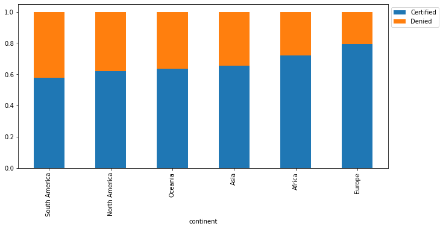

```python
stacked_barplot(visa, "continent", "case_status")
```

```
case_status            Certified  Denied    All
education_of_employee
All                        17018    8462  25480
Bachelor's                  6367    3867  10234
High School                 1164    2256   3420
Master's                    7575    2059   9634
Doctorate                   1912     280   2192
------------------------------------------------------------------------------------------------------------------------
```

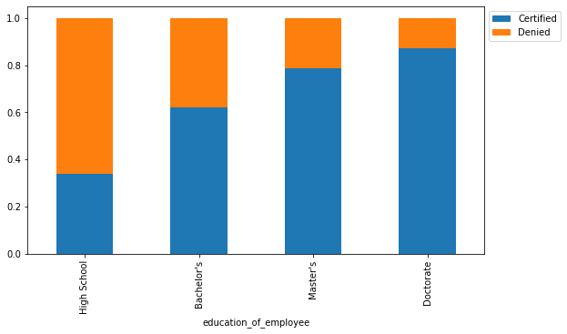

```python
stacked_barplot(visa, "education_of_employee", "case_status")
```

- Doctorate has higher % of Certified cases obviously.
- Bachelor's has around 60% certified cases which is low, considering most of applications are Bachelors.

```
case_status           Certified  Denied    All
region_of_employment
All                       17018    8462  25480
Northeast                  4526    2669   7195
West                       4100    2486   6586
South                      4913    2104   7017
Midwest                    3253    1054   4307
Island                      226     149    375
------------------------------------------------------------------------------------------------------------------------
```

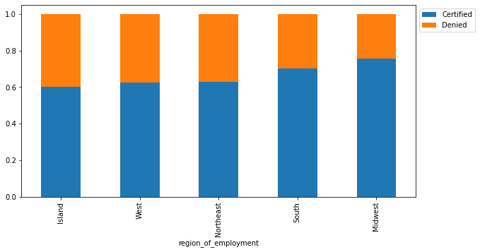

```python
stacked_barplot(visa, "region_of_employment", "case_status")
```

- Region of Employment doesn't seem to have impact, but interestingly Midwest region has good apporval rate.

```
case_status         Certified  Denied    All
full_time_position
All                     17018    8462  25480
Y                       15163    7610  22773
N                        1855     852   2707
------------------------------------------------------------------------------------------------------------------------
```

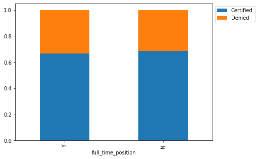

```python
stacked_barplot(visa, "full_time_position", "case_status")
```

- Surprisingly Full time poisiton doesn't have much impact looks like

```
case_status         Certified  Denied    All
has_job_experience
All                     17018    8462  25480
N                        5994    4684  10678
Y                       11024    3778  14802
------------------------------------------------------------------------------------------------------------------------
```

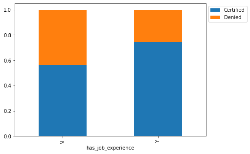

```python
stacked_barplot(visa, "has_job_experience", "case_status")
```

- Having job experience may be a deciding factor from above graph.

```
case_status            Certified  Denied    All
requires_job_training
All                        17018    8462  25480
N                          15012    7513  22525
Y                           2006     949   2955
------------------------------------------------------------------------------------------------------------------------
```

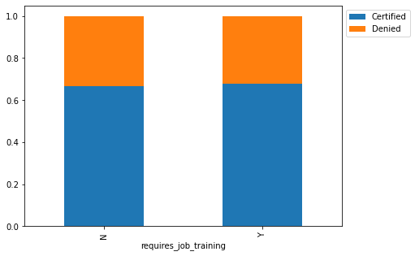

```python
stacked_barplot(visa, "requires_job_training", "case_status")
```

- As we saw above, Job training doesn't seem to have much impact.

```
case_status   Certified  Denied    All
unit_of_wage
All               17018    8462  25480
Year              16047    6915  22962
Hour                747    1410   2157
Week                169     103    272
Month                55      34     89
------------------------------------------------------------------------------------------------------------------------
```

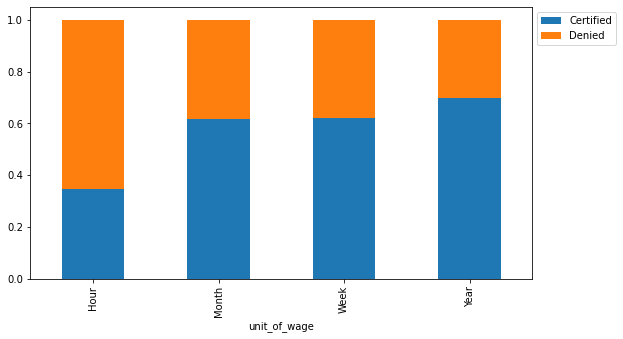

```python
stacked_barplot(visa, "unit_of_wage", "case_status")
```

- Except Hourly wage applications, other unit of wage has almost equal % of success

#### Education vs Prevailing wage

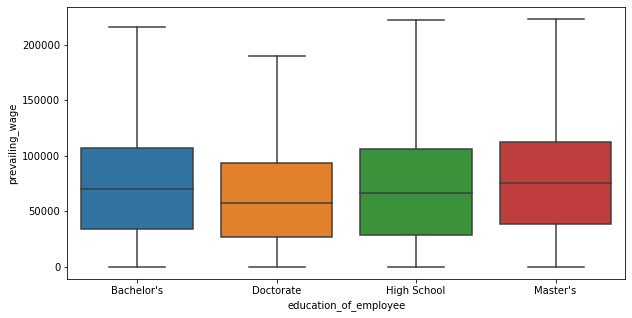

```python
plt.figure(figsize=(10, 5))
sns.boxplot(
    data=visa,
    x="education_of_employee",
    y="prevailing_wage",
    showfliers=False,  # turning off the outliers
)
plt.show()
```

#### Prevaling Wage vs Case Status

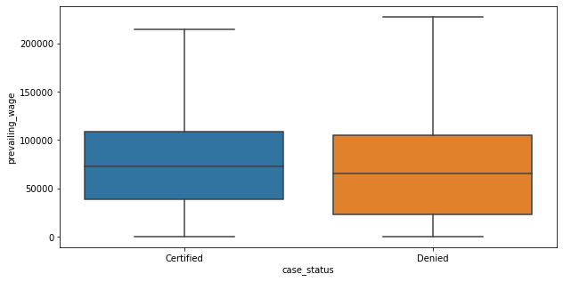

```python
plt.figure(figsize=(10, 5))
sns.boxplot(
    data=visa,
    x="case_status",
    y="prevailing_wage",
    showfliers=False,  # turning off the outliers
)
plt.show()
```

#### Deeper look at Casestatus vs Prevailing Wage

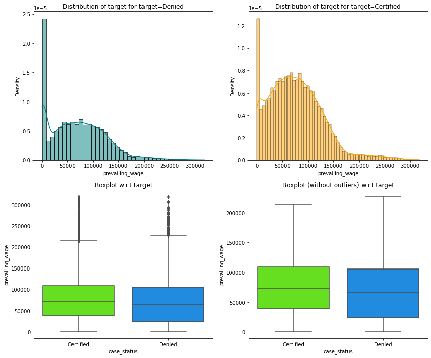

```python
distribution_plot_wrt_target(visa, "prevailing_wage", "case_status")
```

#### No. of Employees vs Casestatus

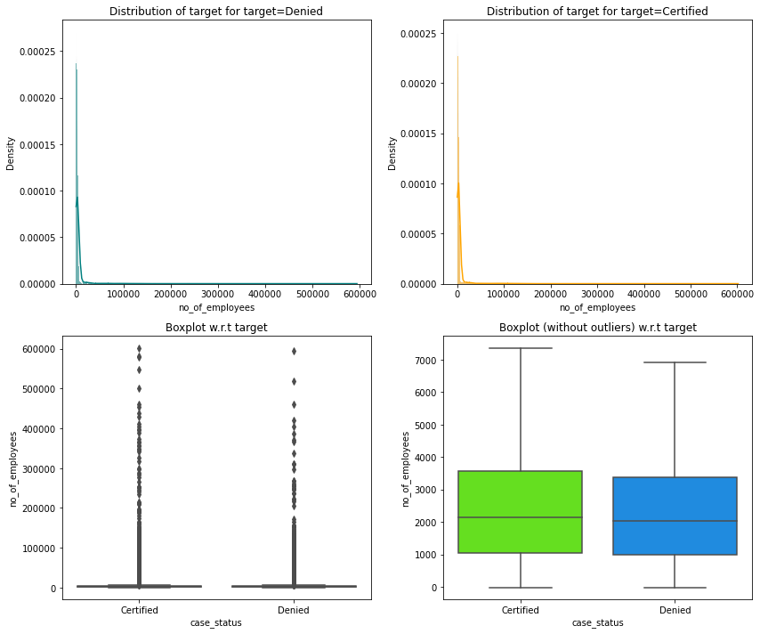

```python
distribution_plot_wrt_target(visa, "no_of_employees", "case_status")
```

#### Organization Employee count across Continents

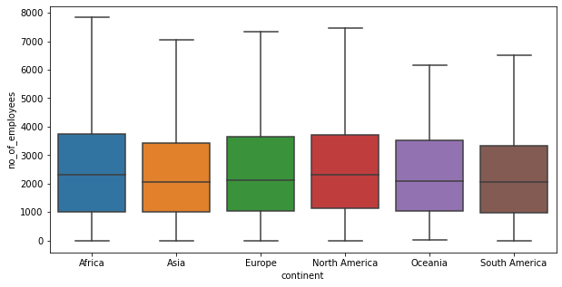

```python
plt.figure(figsize=(10, 5))
sns.boxplot(
    data=visa,
    x="continent",
    y="no_of_employees",
    showfliers=False,  # turning off the outliers
)
plt.show()
```

### Data Preprocessing

#### Hot Encoding

```python
replaceStruct = {
                "education_of_employee": {"High School": 1, "Bachelor's":2 , "Master's": 3,"Doctorate": 4},
                 "requires_job_training":     {"N": 0, "Y": 1},
                 "has_job_experience":     {"N": 0, "Y": 1},
                "full_time_position":     {"N": 0, "Y": 1},
                "case_status":     {"Denied": 0, "Certified": 1}
                }
oneHotCols=["continent","region_of_employment","unit_of_wage"]
```

```python
visa=visa.replace(replaceStruct)
#visa=pd.get_dummies(visa,columns=oneHotCols)
visa.sample(10)
```

|  | case_id | continent | education_of_employee | has_job_experience | requires_job_training | no_of_employees | yr_of_estab | region_of_employment | prevailing_wage | unit_of_wage | full_time_position | case_status |
| --- | --- | --- | --- | --- | --- | --- | --- | --- | --- | --- | --- | --- |
| 4868 | EZYV4869 | Asia | 3 | 0 | 0 | 56 | 2008 | Midwest | 44414.48 | Year | 1 | 1 |
| 3720 | EZYV3721 | North America | 2 | 0 | 0 | 1490 | 2012 | Midwest | 146216.07 | Year | 1 | 0 |
| 303 | EZYV304 | Asia | 2 | 1 | 0 | 2597 | 1945 | West | 155042.99 | Year | 1 | 1 |
| 11050 | EZYV11051 | Asia | 2 | 0 | 0 | 1478 | 1834 | Northeast | 144806.40 | Year | 1 | 0 |
| 25250 | EZYV25251 | Asia | 3 | 0 | 0 | 4389 | 1899 | South | 114515.24 | Year | 0 | 0 |
| 5596 | EZYV5597 | Africa | 3 | 1 | 0 | 1333 | 2003 | Northeast | 122902.21 | Year | 1 | 1 |
| 2819 | EZYV2820 | Asia | 1 | 1 | 0 | 2931 | 1988 | South | 94418.08 | Year | 0 | 0 |
| 10779 | EZYV10780 | Asia | 2 | 1 | 0 | 4208 | 1896 | West | 13271.74 | Year | 1 | 1 |
| 25078 | EZYV25079 | Asia | 3 | 1 | 0 | 2095 | 1898 | Northeast | 68699.86 | Year | 0 | 1 |
| 4778 | EZYV4779 | Asia | 2 | 1 | 0 | 192494 | 2006 | West | 43244.46 | Year | 1 | 1 |

```python
visa.info()
```

```
<class 'pandas.core.frame.DataFrame'>
RangeIndex: 25480 entries, 0 to 25479
Data columns (total 12 columns):
 #   Column                 Non-Null Count  Dtype
---  ------                 --------------  -----
 0   case_id                25480 non-null  category
 1   continent              25480 non-null  category
 2   education_of_employee  25480 non-null  int64
 3   has_job_experience     25480 non-null  int64
 4   requires_job_training  25480 non-null  int64
 5   no_of_employees        25480 non-null  int64
 6   yr_of_estab            25480 non-null  int64
 7   region_of_employment   25480 non-null  category
 8   prevailing_wage        25480 non-null  float64
 9   unit_of_wage           25480 non-null  category
 10  full_time_position     25480 non-null  int64
 11  case_status            25480 non-null  int64
dtypes: category(4), float64(1), int64(7)
memory usage: 2.9 MB
```

- Check data after Encoding.Numeric columns are 8 and 4 string columns

### Outlier Treatment

- No. of employees have negative values let's have a look at it

```python
visa.loc[visa["no_of_employees"]< 0].value_counts()
```

```
case_id    continent      education_of_employee  has_job_experience  requires_job_training  no_of_employees  yr_of_estab  region_of_employment  prevailing_wage  unit_of_wage  full_time_position  case_status
EZYV11494  Asia           1                      1                   0                      -14              1999         South                 27599.35         Year          1                   0              1
EZYV21945  Africa         3                      1                   0                      -25              1977         Midwest               79150.51         Year          1                   1              1
EZYV833    South America  3                      1                   0                      -17              2002         South                 129701.94        Year          1                   1              1
EZYV7762   Asia           3                      0                   0                      -11              2009         Midwest               38457.51         Year          1                   1              1
EZYV7319   Asia           2                      1                   1                      -26              2006         South                 115005.61        Year          1                   1              1
EZYV7282   Asia           1                      0                   0                      -14              2000         Midwest               58488.50         Year          1                   0              1
EZYV7225   Europe         4                      0                   0                      -25              1998         Midwest               141435.95        Year          1                   1              1
EZYV6635   Asia           2                      1                   0                      -26              1923         West                  5247.32          Year          1                   0              1
EZYV6440   Asia           2                      0                   0                      -14              2013         South                 103.97           Hour          1                   0              1
EZYV379    Asia           2                      0                   1                      -11              2011         Northeast             32506.14         Year          1                   0              1
EZYV2919   Asia           3                      1                   0                      -26              2005         Midwest               112799.46        Year          1                   1              1
EZYV246    Europe         3                      0                   0                      -25              1980         Northeast             39452.99         Year          1                   1              1
EZYV23477  Europe         3                      1                   0                      -11              2000         West                  95072.75         Year          1                   0              1
EZYV23187  Asia           3                      0                   1                      -11              2007         Midwest               120195.35        Year          1                   1              1
EZYV22389  Asia           3                      1                   0                      -14              1986         South                 17893.11         Year          1                   1              1
EZYV22085  North America  2                      1                   0                      -14              1980         West                  691.06           Hour          1                   0              1
EZYV21761  Asia           2                      1                   0                      -25              2000         West                  100463.58        Year          1                   1              1
EZYV13472  North America  3                      0                   0                      -17              2003         Northeast             257.24           Hour          1                   0              1
EZYV21256  North America  1                      0                   0                      -25              1987         South                 99405.47         Year          0                   0              1
EZYV20985  Europe         4                      1                   0                      -14              1989         Midwest               37012.80         Year          1                   1              1
EZYV20816  Asia           2                      0                   1                      -17              1990         West                  91897.57         Year          1                   1              1
EZYV17984  Asia           2                      0                   0                      -26              2004         South                 84359.98         Year          1                   0              1
```

[output cut: 12 more lines]

```python
visa.loc[visa["no_of_employees"]< 0,"no_of_employees"]= visa["no_of_employees"] * -1
```

- Convert them to positive as they are very less rows.

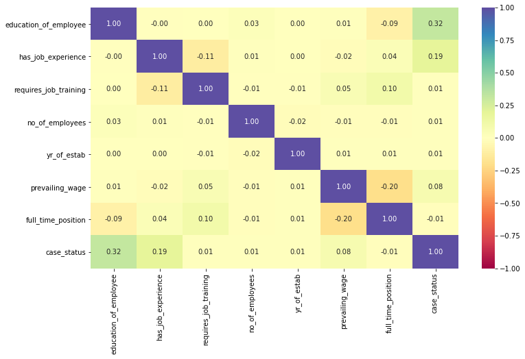

```python
cols_list = visa.select_dtypes(include=np.number).columns.tolist()

plt.figure(figsize=(12, 7))
sns.heatmap(
    visa[cols_list].corr(), annot=True, vmin=-1, vmax=1, fmt=".2f", cmap="Spectral"
)
plt.show()
```

- Not much Correlation between any of the values, Except Education has positive Correlation with Case_status.
- Job Experience has positive correlation with case status
- Prevailing wage has negative correlation with Full time position that is odd
- Do some pair plot to identify ufrhter relation ships

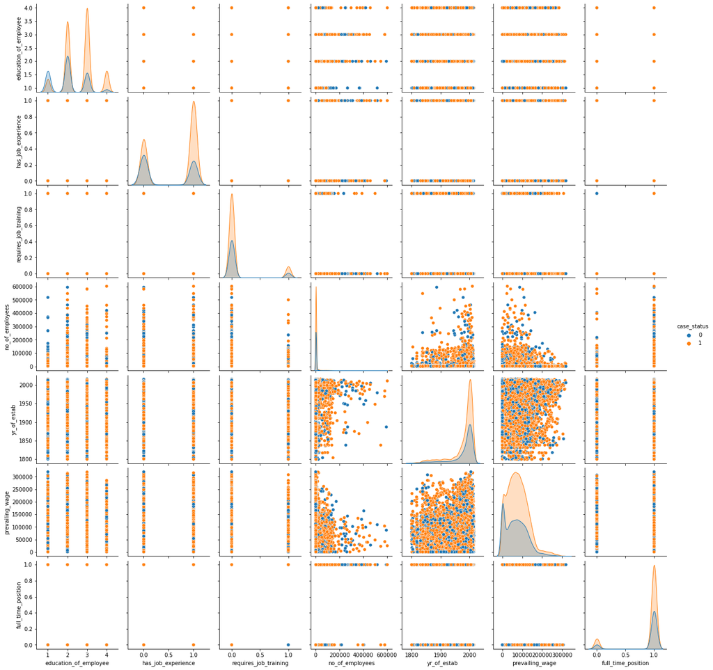

```python
sns.pairplot(visa,hue='case_status')
plt.show()
```

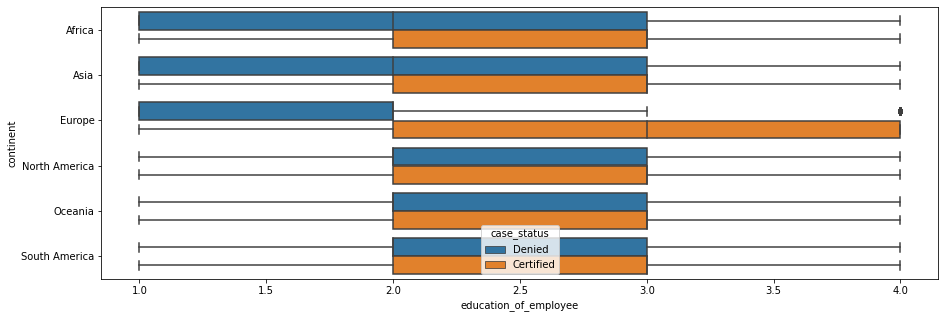

```python
plt.figure(figsize=(15,5))
sns.boxplot(visa['education_of_employee'],visa['continent'],hue=data['case_status'])
plt.show()
```

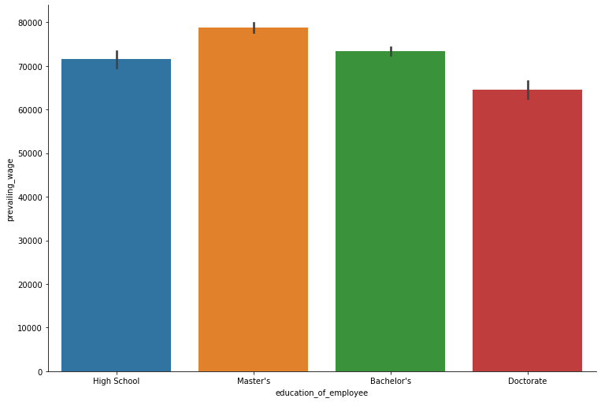

```python
sns.catplot(x="education_of_employee", y="prevailing_wage", data=data, kind='bar', height=7, aspect=1.5, estimator=np.mean);
```

- Masters seems to have Higher prevailing wages compared to Doctorate applicants

## Data Preprocessing

```python
# Function to convert Wage to Yearly wage
def ConvertWage(x,y):
    if x=='Hour':
        y= y*7*5*43
    if x=='Week':
        y=y*52
    if x=='Month':
        y=y*12
    return y
```

```python
visa['prevailing_wage']=visa.apply(lambda x: ConvertWage(x.unit_of_wage,x.prevailing_wage),axis=1)
```

```python
#Dropping columns as it will not impact prediction
visa.drop(columns=['case_id'], inplace=True)
visa.drop(columns=['unit_of_wage'], inplace=True)
```

```python
visa.loc[visa["prevailing_wage"]< 10000].value_counts()
```

```
continent      education_of_employee  has_job_experience  requires_job_training  no_of_employees  yr_of_estab  region_of_employment  prevailing_wage  full_time_position  case_status
Africa         1                      0                   0                      1399             2006         West                  6897.50          1                   0              1
Europe         3                      0                   0                      3080             1976         South                 8988.59          1                   1              1
                                                                                 3196             2005         Midwest               4110.43          1                   1              1
                                                                                 3382             1847         West                  5637.79          1                   1              1
                                                                                 4106             1902         South                 126.28           1                   1              1
                                                                                                                                                                                        ..
Asia           3                      0                   1                      2846             1978         South                 9012.89          1                   1              1
                                                                                 3103             1999         West                  8826.61          1                   1              1
                                                                                 3213             1985         West                  1234.57          1                   1              1
                                      1                   0                      69               1987         Midwest               6764.58          1                   1              1
South America  4                      0                   1                      2966             1946         West                  9761.80          1                   1              1
Length: 1048, dtype: int64
```

- Annual wage less than 10,000 $, seems outlier data. We can drop these data for Model Evaluation

```python
visa = visa.drop(visa[visa["prevailing_wage"]<10000].index)
```

```python
visa.shape
```

```
(24432, 10)
```

```python
visa.sample(25)
```

|  | continent | education_of_employee | has_job_experience | requires_job_training | no_of_employees | yr_of_estab | region_of_employment | prevailing_wage | full_time_position | case_status |
| --- | --- | --- | --- | --- | --- | --- | --- | --- | --- | --- |
| 4281 | North America | 3 | 0 | 0 | 3032 | 1960 | West | 66903.34 | 1 | 0 |
| 1770 | North America | 2 | 1 | 0 | 128 | 1833 | Midwest | 982781.16 | 1 | 1 |
| 11231 | North America | 3 | 0 | 0 | 593 | 1838 | West | 252759.33 | 1 | 0 |
| 20157 | Asia | 2 | 1 | 0 | 1432 | 1995 | West | 87361.06 | 1 | 1 |
| 16780 | Asia | 3 | 1 | 0 | 2978 | 2013 | Midwest | 131814.12 | 0 | 1 |
| 3268 | North America | 3 | 1 | 0 | 1512 | 2004 | South | 52336.12 | 0 | 1 |
| 21918 | Asia | 3 | 1 | 0 | 2628 | 1877 | West | 2731208.48 | 1 | 0 |
| 1261 | Asia | 3 | 0 | 1 | 3405 | 2014 | South | 53826.46 | 1 | 1 |
| 5720 | South America | 4 | 0 | 1 | 310 | 1985 | Northeast | 536997.09 | 1 | 1 |
| 8038 | Oceania | 1 | 1 | 0 | 1039 | 2004 | West | 53717.74 | 0 | 1 |
| 25343 | Asia | 3 | 1 | 0 | 53376 | 1875 | South | 58641.89 | 1 | 1 |
| 13453 | Asia | 2 | 0 | 0 | 2499 | 2009 | Midwest | 105604.70 | 0 | 1 |
| 23512 | Asia | 3 | 0 | 0 | 2157 | 1998 | Midwest | 73043.48 | 0 | 0 |
| 10561 | Asia | 1 | 0 | 1 | 4501 | 1926 | South | 106202.10 | 1 | 0 |
| 310 | Asia | 3 | 1 | 1 | 954 | 1988 | West | 56065.53 | 1 | 1 |
| 15157 | Asia | 4 | 0 | 0 | 1096 | 2001 | West | 139482.71 | 1 | 1 |
| 17256 | Asia | 2 | 1 | 0 | 2280 | 2001 | South | 119656.55 | 1 | 1 |
| 20599 | Asia | 3 | 1 | 0 | 3956 | 1998 | West | 39184.72 | 1 | 1 |
| 471 | Asia | 3 | 0 | 0 | 1571 | 1996 | West | 143415.79 | 0 | 0 |
| 20097 | Asia | 3 | 1 | 0 | 4474 | 1971 | South | 122511.00 | 0 | 1 |
| 13680 | Asia | 4 | 1 | 0 | 2121 | 1984 | South | 1161117.13 | 1 | 1 |
| 17300 | Asia | 3 | 0 | 0 | 3256 | 1986 | Northeast | 32517.28 | 1 | 0 |
| 15245 | Asia | 2 | 1 | 0 | 875 | 1984 | Midwest | 74411.63 | 1 | 1 |
| 25185 | South America | 1 | 0 | 0 | 4785 | 1984 | Midwest | 74839.57 | 1 | 0 |
| 17648 | Asia | 3 | 0 | 0 | 2918 | 2005 | South | 43275.78 | 1 | 0 |

#### Prevailing wage vs Case Status after Preprocessing

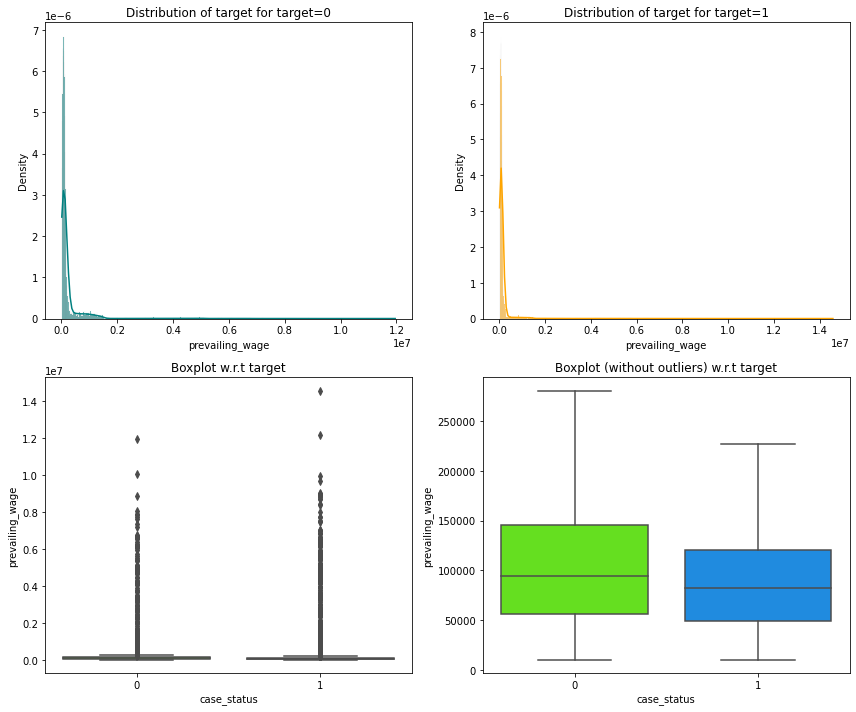

```python
distribution_plot_wrt_target(visa, "prevailing_wage", "case_status")
```

```python
# Separating features and the target column
X = visa.drop(['case_status'], axis=1)
X = pd.get_dummies(X,columns=X.select_dtypes(include=["object", "category"]).columns.tolist(),drop_first=True)
y = visa['case_status']
```

```python
# Splitting the data into train and test sets in 70:30 ratio
X_train, X_test, y_train, y_test = train_test_split(X, y, test_size=0.30, random_state=1, shuffle=True)
print(X_train.shape, X_test.shape)
```

```
(17102, 16) (7330, 16)
```

```python
X_train.shape, X_test.shape
```

```
((17102, 16), (7330, 16))
```

## Building bagging and boosting models

```python
# defining a function to compute different metrics to check performance of a classification model built using sklearn
def model_performance_classification_sklearn(model, predictors, target):
    """
    Function to compute different metrics to check classification model performance

    model: classifier
    predictors: independent variables
    target: dependent variable
    """

    # predicting using the independent variables
    pred = model.predict(predictors)

    acc = accuracy_score(target, pred)  # to compute Accuracy
    recall = recall_score(target, pred)  # to compute Recall
    precision = precision_score(target, pred)  # to compute Precision
    f1 = f1_score(target, pred)  # to compute F1-score

    # creating a dataframe of metrics
    df_perf = pd.DataFrame(
        {
            "Accuracy": acc,
            "Recall": recall,
            "Precision": precision,
            "F1": f1,
        },
        index=[0],
    )

    return df_perf
```

```python
def confusion_matrix_sklearn(model, predictors, target):
    """
    To plot the confusion_matrix with percentages

    model: classifier
    predictors: independent variables
    target: dependent variable
    """
    y_pred = model.predict(predictors)
    cm = confusion_matrix(target, y_pred)
    labels = np.asarray(
        [
            ["{0:0.0f}".format(item) + "\n{0:.2%}".format(item / cm.flatten().sum())]
            for item in cm.flatten()
        ]
    ).reshape(2, 2)

    plt.figure(figsize=(6, 4))
    sns.heatmap(cm, annot=labels, fmt="")
    plt.ylabel("True label")
    plt.xlabel("Predicted label")
```

Predications can be

- Predicting an application will get Certified but in reality the Application will be denied.
- Predicting an application will get denied but in relaity the application gets certified.

**Here both is valuable, so going by F1 score (reduce FP and FN)**

### Decision Tree Model

```python
dtree = DecisionTreeClassifier(criterion='gini',random_state=1)
dtree.fit(X_train,y_train)
```

```
DecisionTreeClassifier(random_state=1)
```

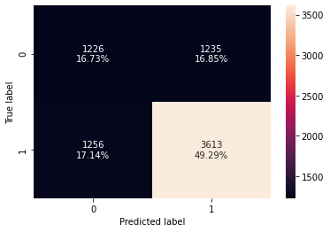

```python
confusion_matrix_sklearn(dtree, X_test, y_test)
```

```python
dtree_model_train_perf=model_performance_classification_sklearn(dtree, X_train,y_train)
print("Training performance \n",dtree_model_train_perf)
```

```
Training performance
    Accuracy  Recall  Precision   F1
0      1.00    1.00       1.00 1.00
```

```python
dtree_model_test_perf=model_performance_classification_sklearn(dtree, X_test,y_test)
print("Testing performance \n",dtree_model_test_perf)
```

```
Testing performance
    Accuracy  Recall  Precision   F1
0      0.66    0.74       0.75 0.74
```

### Bagging Model

```python
bagging = BaggingClassifier(random_state=1)
bagging.fit(X_train,y_train)
```

```
BaggingClassifier(random_state=1)
```

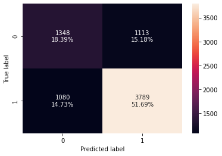

```python
confusion_matrix_sklearn(bagging, X_test, y_test)
```

```python
bagging_model_train_perf=model_performance_classification_sklearn(bagging, X_train, y_train)
print("Training performance \n",bagging_model_train_perf)
```

```
Training performance
    Accuracy  Recall  Precision   F1
0      0.99    0.99       0.99 0.99
```

```python
bagging_model_test_perf=model_performance_classification_sklearn(bagging, X_test, y_test)
print("Testing performance \n",bagging_model_test_perf)
```

```
Testing performance
    Accuracy  Recall  Precision   F1
0      0.70    0.78       0.77 0.78
```

#### Bagging Classifier with weighted decision tree

```python
bagging_wt = BaggingClassifier(base_estimator=DecisionTreeClassifier(criterion='gini',class_weight={0:0.17,1:0.83},random_state=1),random_state=1)
bagging_wt.fit(X_train,y_train)
```

```
BaggingClassifier(base_estimator=DecisionTreeClassifier(class_weight={0: 0.17,
                                                                      1: 0.83},
                                                        random_state=1),
                  random_state=1)
```

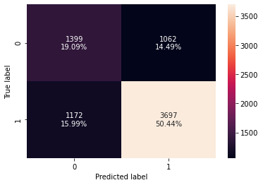

```python
confusion_matrix_sklearn(bagging_wt,X_test,y_test)
```

```python
bagging_wt_model_train_perf=model_performance_classification_sklearn(bagging_wt,X_train,y_train)
print("Training performance \n",bagging_wt_model_train_perf)
```

```
Training performance
    Accuracy  Recall  Precision   F1
0      0.98    0.98       0.99 0.99
```

```python
bagging_wt_model_test_perf=model_performance_classification_sklearn(bagging_wt, X_test, y_test)
print("Testing performance \n",bagging_wt_model_test_perf)
```

```
Testing performance
    Accuracy  Recall  Precision   F1
0      0.70    0.76       0.78 0.77
```

### Random Forest

```python
rf = RandomForestClassifier(random_state=1)
rf.fit(X_train,y_train)
```

```
RandomForestClassifier(random_state=1)
```

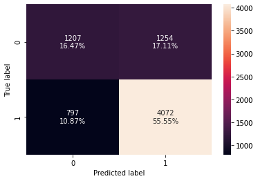

```python
confusion_matrix_sklearn(rf,X_test,y_test)
```

```python
rf_model_train_perf=model_performance_classification_sklearn(rf,X_train,y_train)
print("Training performance \n",rf_model_train_perf)
```

```
Training performance
    Accuracy  Recall  Precision   F1
0      1.00    1.00       1.00 1.00
```

```python
rf_model_test_perf=model_performance_classification_sklearn(rf,X_test,y_test)
print("Testing performance \n",rf_model_test_perf)
```

```
Testing performance
    Accuracy  Recall  Precision   F1
0      0.72    0.84       0.76 0.80
```

```python
rf_wt = RandomForestClassifier(random_state=1)
rf_wt.fit(X_train,y_train)
```

```
RandomForestClassifier(random_state=1)
```

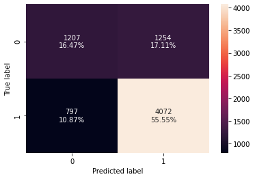

```python
confusion_matrix_sklearn(rf_wt, X_test,y_test)
```

```python
rf_wt_model_train_perf=model_performance_classification_sklearn(rf_wt, X_train,y_train)
print("Training performance \n",rf_wt_model_train_perf)
```

```
Training performance
    Accuracy  Recall  Precision   F1
0      1.00    1.00       1.00 1.00
```

```python
rf_wt_model_test_perf=model_performance_classification_sklearn(rf_wt, X_test,y_test)
print("Testing performance \n",rf_wt_model_test_perf)
```

```
Testing performance
    Accuracy  Recall  Precision   F1
0      0.72    0.84       0.76 0.80
```

#### Tuning Decision Tree

```python
# Choose the type of classifier.
dtree_estimator = DecisionTreeClassifier(random_state=1)

# Grid of parameters to choose from
parameters = {'max_depth': [5, 10, 15, None],
               "criterion": ["entropy", "gini"],
                "splitter": ["best", "random"],
              'min_samples_leaf': [1, 2, 5],
              'max_leaf_nodes' : [2, 3, 5],
              'min_impurity_decrease': [0.0001,0.001,0.01,0.1]
             }

# Type of scoring used to compare parameter combinations
scorer = metrics.make_scorer(metrics.f1_score)

# Run the grid search
grid_obj = GridSearchCV(dtree_estimator, parameters, scoring=scorer)
grid_obj = grid_obj.fit(X_train, y_train)

# Set the clf to the best combination of parameters
dtree_estimator = grid_obj.best_estimator_

# Fit the best algorithm to the data.
dtree_estimator.fit(X_train, y_train)
```

```
DecisionTreeClassifier(max_depth=5, max_leaf_nodes=5,
                       min_impurity_decrease=0.0001, random_state=1)
```

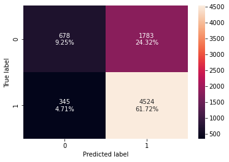

```python
confusion_matrix_sklearn(dtree_estimator, X_test,y_test)
```

```python
dtree_estimator_model_train_perf=model_performance_classification_sklearn(dtree_estimator, X_train,y_train)
print("Training performance \n",dtree_estimator_model_train_perf)
```

```
Training performance
    Accuracy  Recall  Precision   F1
0      0.71    0.93       0.72 0.81
```

```python
dtree_estimator_model_test_perf=model_performance_classification_sklearn(dtree_estimator, X_test, y_test)
print("Testing performance \n",dtree_estimator_model_test_perf)
```

```
Testing performance
    Accuracy  Recall  Precision   F1
0      0.71    0.93       0.72 0.81
```

```python
# importance of features in the tree building ( The importance of a feature is computed as the
#(normalized) total reduction of the criterion brought by that feature. It is also known as the Gini importance )

print(pd.DataFrame(dtree_estimator.feature_importances_, columns = ["Imp"], index = X_train.columns).sort_values(by = 'Imp', ascending = False))
```

```
                                Imp
education_of_employee          0.64
has_job_experience             0.28
continent_Europe               0.08
requires_job_training          0.00
no_of_employees                0.00
yr_of_estab                    0.00
prevailing_wage                0.00
full_time_position             0.00
continent_Asia                 0.00
continent_North America        0.00
continent_Oceania              0.00
continent_South America        0.00
region_of_employment_Midwest   0.00
region_of_employment_Northeast 0.00
region_of_employment_South     0.00
region_of_employment_West      0.00
```

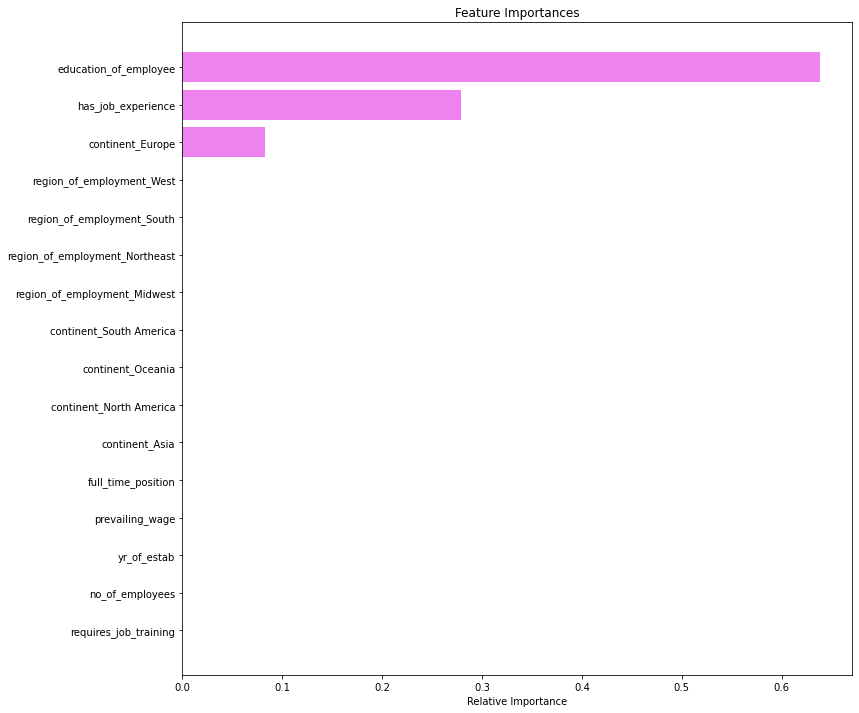

```python
feature_names = X_train.columns
importances = dtree_estimator.feature_importances_
indices = np.argsort(importances)

plt.figure(figsize=(12,12))
plt.title('Feature Importances')
plt.barh(range(len(indices)), importances[indices], color='violet', align='center')
plt.yticks(range(len(indices)), [feature_names[i] for i in indices])
plt.xlabel('Relative Importance')
plt.show()
```

- Tuning Decision tree model lists out Education of Employee as the top most influencing feature followed by Job Experience and Europe Continent

#### Tuning Random Forest

```python
# Choose the type of classifier.
rf_estimator = RandomForestClassifier(random_state=1)
# Grid of parameters to choose from
parameters = {
                'max_depth':[4, 6,  None],
                'max_features': ['sqrt','log2',None],
                'n_estimators': [80, 90, 100]
}
# Run the grid search
grid_obj = GridSearchCV(rf_estimator, parameters, scoring='f1',cv=5)
grid_obj = grid_obj.fit(X_train.sample(frac = 0.5), y_train.sample(frac = 0.5))

# Set the clf to the best combination of parameters
rf_estimator = grid_obj.best_estimator_

# Fit the best algorithm to the data.
rf_estimator.fit(X_train, y_train)
```

```
RandomForestClassifier(max_depth=4, max_features='sqrt', n_estimators=80,
                       random_state=1)
```

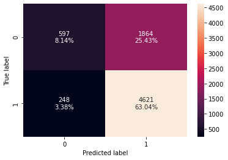

```python
confusion_matrix_sklearn(rf_estimator, X_test,y_test)
```

```python
rf_estimator_model_train_perf=model_performance_classification_sklearn(rf_estimator, X_train,y_train)
print("Training performance \n",rf_estimator_model_train_perf)
```

```
Training performance
    Accuracy  Recall  Precision   F1
0      0.72    0.95       0.72 0.82
```

```python
rf_estimator_model_test_perf=model_performance_classification_sklearn(rf_estimator, X_test, y_test)
print("Testing performance \n",rf_estimator_model_test_perf)
```

```
Testing performance
    Accuracy  Recall  Precision   F1
0      0.71    0.95       0.71 0.81
```

```python
# importance of features in the tree building ( The importance of a feature is computed as the
#(normalized) total reduction of the criterion brought by that feature. It is also known as the Gini importance )

print(pd.DataFrame(rf_estimator.feature_importances_, columns = ["Imp"], index = X_train.columns).sort_values(by = 'Imp', ascending = False))
```

```
                                Imp
education_of_employee          0.46
has_job_experience             0.25
prevailing_wage                0.13
continent_Europe               0.06
region_of_employment_Midwest   0.03
region_of_employment_West      0.02
region_of_employment_Northeast 0.01
no_of_employees                0.01
continent_North America        0.01
continent_Asia                 0.01
region_of_employment_South     0.01
yr_of_estab                    0.00
requires_job_training          0.00
continent_South America        0.00
full_time_position             0.00
continent_Oceania              0.00
```

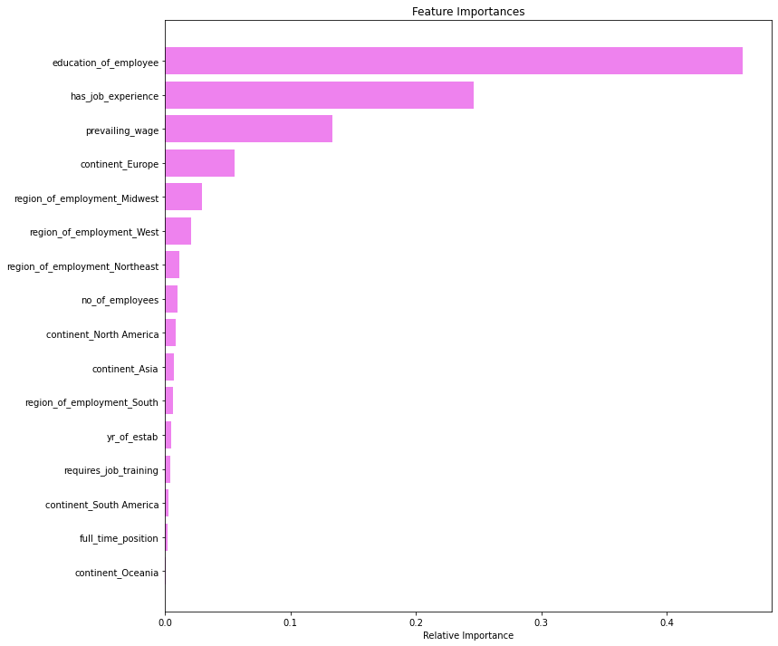

```python
feature_names = X_train.columns
importances = rf_estimator.feature_importances_
indices = np.argsort(importances)

plt.figure(figsize=(12,12))
plt.title('Feature Importances')
plt.barh(range(len(indices)), importances[indices], color='violet', align='center')
plt.yticks(range(len(indices)), [feature_names[i] for i in indices])
plt.xlabel('Relative Importance')
plt.show()
```

#### Tuning Bagging Classifier

```python
# grid search for bagging classifier
cl1 = DecisionTreeClassifier(class_weight={0:0.13,1:0.87},random_state=1)
param_grid = {'base_estimator':[cl1],
              'n_estimators':[5,7,15],
              'max_features': [0.7,0.8,0.9,1]
             }

grid = GridSearchCV(BaggingClassifier(random_state=1,bootstrap=True), param_grid=param_grid, scoring = 'f1', cv = 5)
grid.fit(X_train, y_train)
```

```
GridSearchCV(cv=5, estimator=BaggingClassifier(random_state=1),
             param_grid={'base_estimator': [DecisionTreeClassifier(class_weight={0: 0.13,
                                                                                 1: 0.87},
                                                                   random_state=1)],
                         'max_features': [0.7, 0.8, 0.9, 1],
                         'n_estimators': [5, 7, 15]},
             scoring='f1')
```

```python
## getting the best estimator
bagging_estimator  = grid.best_estimator_
bagging_estimator.fit(X_train,y_train)
```

```
BaggingClassifier(base_estimator=DecisionTreeClassifier(class_weight={0: 0.13,
                                                                      1: 0.87},
                                                        random_state=1),
                  max_features=1, n_estimators=5, random_state=1)
```

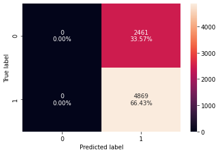

```python
confusion_matrix_sklearn(bagging_estimator, X_test,y_test)
```

```python
bagging_estimator_model_train_perf=model_performance_classification_sklearn(bagging_estimator, X_train,y_train)
print("Training performance \n",bagging_estimator_model_train_perf)
```

```
Training performance
    Accuracy  Recall  Precision   F1
0      0.67    1.00       0.67 0.80
```

```python
bagging_estimator_model_test_perf=model_performance_classification_sklearn(bagging_estimator, X_test, y_test)
print("Testing performance \n",bagging_estimator_model_test_perf)
```

```
Testing performance
    Accuracy  Recall  Precision   F1
0      0.66    1.00       0.66 0.80
```

### Boosting Model

#### AdaBoostClassifier

```python
ab=AdaBoostClassifier(random_state=1)
ab.fit(X_train,y_train)
```

```
AdaBoostClassifier(random_state=1)
```

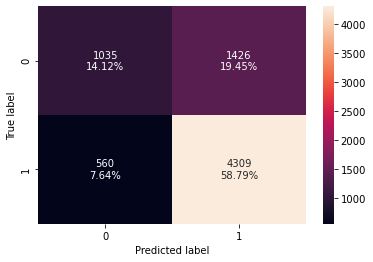

```python
confusion_matrix_sklearn(ab, X_test,y_test)
```

```python
ab_model_train_perf = model_performance_classification_sklearn(ab, X_train,y_train)
print("Training performance \n",ab_model_train_perf)
```

```
Training performance
    Accuracy  Recall  Precision   F1
0      0.73    0.89       0.75 0.81
```

```python
ab_model_test_perf = model_performance_classification_sklearn(ab,X_test,y_test)
print("Testing performance \n",ab_model_test_perf)
```

```
Testing performance
    Accuracy  Recall  Precision   F1
0      0.73    0.88       0.75 0.81
```

```python
# Choose the type of classifier.
ab_tuned = AdaBoostClassifier(random_state=1)

# Grid of parameters to choose from
parameters = {'n_estimators':  [110,125,50],
              'learning_rate': [1, 0.1, 0.5, 0.01],
              }

# Type of scoring used to compare parameter combinations
scorer = metrics.make_scorer(metrics.f1_score)

# Run the grid search
grid_obj = GridSearchCV(ab_tuned, parameters, scoring=scorer,cv=5)
grid_obj = grid_obj.fit(X_train, y_train)

# Set the clf to the best combination of parameters
ab_tuned = grid_obj.best_estimator_

# Fit the best algorithm to the data.
ab_tuned.fit(X_train, y_train)
```

```
AdaBoostClassifier(learning_rate=0.5, n_estimators=125, random_state=1)
```

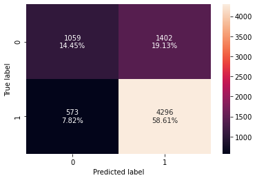

```python
confusion_matrix_sklearn(ab_tuned, X_test,y_test)
```

```python
ab_tuned_model_train_perf = model_performance_classification_sklearn(ab_tuned, X_train,y_train)
print("Training performance \n",ab_tuned_model_train_perf)
```

```
Training performance
    Accuracy  Recall  Precision   F1
0      0.73    0.89       0.75 0.81
```

```python
ab_tuned_model_test_perf = model_performance_classification_sklearn(ab_tuned, X_test,y_test)
print("Testing performance \n",ab_tuned_model_train_perf)
```

```
Testing performance
    Accuracy  Recall  Precision   F1
0      0.73    0.89       0.75 0.81
```

#### Gradient Boosting Classifier

```python
gb_estimator=GradientBoostingClassifier(random_state=1)
gb_estimator.fit(X_train,y_train)
```

```
GradientBoostingClassifier(random_state=1)
```

```python
gb_estimator_model_train_perf = model_performance_classification_sklearn(gb_estimator, X_train,y_train)
print("Training performance \n",gb_estimator_model_train_perf)
```

```
Training performance
    Accuracy  Recall  Precision   F1
0      0.75    0.88       0.78 0.82
```

```python
gb_estimator_model_test_perf = model_performance_classification_sklearn(gb_estimator, X_test, y_test)
print("Testing performance \n",gb_estimator_model_test_perf)
```

```
Testing performance
    Accuracy  Recall  Precision   F1
0      0.74    0.87       0.77 0.82
```

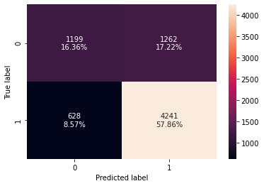

```python
confusion_matrix_sklearn(gb_estimator, X_test,y_test)
```

```python
# Choose the type of classifier.
gb_tuned = GradientBoostingClassifier(random_state=1)

# Grid of parameters to choose from
parameters = {'n_estimators':  [110,50],
              'subsample':[0.9,1],
              'max_depth':[7,10]
              }

# Type of scoring used to compare parameter combinations
scorer = metrics.make_scorer(metrics.f1_score)

# Run the grid search
grid_obj = GridSearchCV(gb_tuned, parameters, scoring=scorer,cv=5)
grid_obj = grid_obj.fit(X_train.sample(frac = 0.5), y_train.sample(frac = 0.5))

# Set the clf to the best combination of parameters
gb_tuned = grid_obj.best_estimator_

# Fit the best algorithm to the data.
gb_tuned.fit(X_train, y_train)
```

```
GradientBoostingClassifier(max_depth=7, n_estimators=50, random_state=1,
                           subsample=1)
```

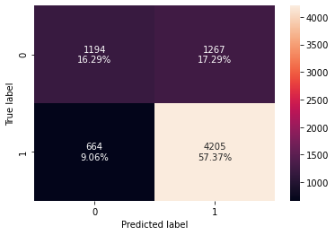

```python
confusion_matrix_sklearn(gb_tuned, X_test,y_test)
```

```python
gb_tuned_model_train_perf = model_performance_classification_sklearn(gb_tuned, X_train,y_train)
print("Training performance \n",gb_tuned_model_train_perf)
```

```
Training performance
    Accuracy  Recall  Precision   F1
0      0.79    0.90       0.81 0.85
```

```python
gb_tuned_model_test_perf = model_performance_classification_sklearn(gb_tuned, X_test, y_test)
print("Testing performance \n",gb_tuned_model_test_perf)
```

```
Testing performance
    Accuracy  Recall  Precision   F1
0      0.74    0.86       0.77 0.81
```

```python
estimators=[('Decision Tree', dtree_estimator),('Random Forest', rf_estimator),
           ('Gradient Boosting', gb_tuned),('Ada Boosting', ab_tuned)]
final_estimator=XGBClassifier(random_state=1)
```

```python
stacking_estimator=StackingClassifier(estimators=estimators, final_estimator=final_estimator,cv=5)
stacking_estimator.fit(X_train,y_train)
```

[output not shown]

```
StackingClassifier(cv=5,
                   estimators=[('Decision Tree',
                                DecisionTreeClassifier(max_depth=5,
                                                       max_leaf_nodes=5,
                                                       min_impurity_decrease=0.0001,
                                                       random_state=1)),
                               ('Random Forest',
                                RandomForestClassifier(max_depth=4,
                                                       max_features='sqrt',
                                                       n_estimators=80,
                                                       random_state=1)),
                               ('Gradient Boosting',
                                GradientBoostingClassifier(max_depth=7,
                                                           n_estimators=50,
                                                           random_state=1,
                                                           subsam...
                                                 interaction_constraints=None,
                                                 learning_rate=None,
                                                 max_delta_step=None,
                                                 max_depth=None,
                                                 min_child_weight=None,
                                                 missing=nan,
                                                 monotone_constraints=None,
                                                 n_estimators=100, n_jobs=None,
                                                 num_parallel_tree=None,
                                                 predictor=None, random_state=1,
                                                 reg_alpha=None,
                                                 reg_lambda=None,
                                                 scale_pos_weight=None,
                                                 subsample=None,
                                                 tree_method=None,
                                                 validate_parameters=None,
                                                 verbosity=None))
```

```python
stacking_estimator_model_train_perf = model_performance_classification_sklearn(stacking_estimator, X_train, y_train)
print("Training performance \n",stacking_estimator_model_train_perf)
```

```
Training performance
    Accuracy  Recall  Precision   F1
0      0.75    0.88       0.77 0.82
```

```python
stacking_estimator_model_test_perf = model_performance_classification_sklearn(stacking_estimator, X_test, y_test)
print("Testing performance \n",stacking_estimator_model_test_perf)
```

```
Testing performance
    Accuracy  Recall  Precision   F1
0      0.73    0.86       0.76 0.81
```

## Model Performance Comparison and Conclusions

```python
# training performance comparison

models_train_comp_df = pd.concat(
    [
dtree_model_train_perf.T, dtree_estimator_model_train_perf.T, rf_model_train_perf.T,rf_wt_model_train_perf.T,
     rf_estimator_model_train_perf.T,bagging_model_train_perf.T,bagging_wt_model_train_perf.T,bagging_estimator_model_train_perf.T,
    ab_model_train_perf.T,ab_tuned_model_train_perf.T,gb_estimator_model_train_perf.T,gb_tuned_model_train_perf.T,
   stacking_estimator_model_train_perf.T],
    axis=1,
)

models_train_comp_df.columns = [
    "Decision Tree",
    "Decision Tree Tuned",
    "Random Forest Estimator",
      "Random Forest Weights",
    "Random Forest Tuned",
    "Bagging",
    "Bagging Weights",
    "Bagging Tuned",
    "Adaboost Classifier",
    "Adaboost Tuned",
    "Gradient Boost Estimator",
    "Gradient Boost Tuned",
    "Stacking Classifier"
]

print("Training performance comparison:")
models_train_comp_df
```

```
Training performance comparison:
```

|  | Decision Tree | Decision Tree Tuned | Random Forest Estimator | Random Forest Weights | Random Forest Tuned | Bagging | Bagging Weights | Bagging Tuned | Adaboost Classifier | Adaboost Tuned | Gradient Boost Estimator | Gradient Boost Tuned | Stacking Classifier |
| --- | --- | --- | --- | --- | --- | --- | --- | --- | --- | --- | --- | --- | --- |
| Accuracy | 1.00 | 0.71 | 1.00 | 1.00 | 0.72 | 0.99 | 0.98 | 0.67 | 0.73 | 0.73 | 0.75 | 0.79 | 0.75 |
| Recall | 1.00 | 0.93 | 1.00 | 1.00 | 0.95 | 0.99 | 0.98 | 1.00 | 0.89 | 0.89 | 0.88 | 0.90 | 0.88 |
| Precision | 1.00 | 0.72 | 1.00 | 1.00 | 0.72 | 0.99 | 0.99 | 0.67 | 0.75 | 0.75 | 0.78 | 0.81 | 0.77 |
| F1 | 1.00 | 0.81 | 1.00 | 1.00 | 0.82 | 0.99 | 0.99 | 0.80 | 0.81 | 0.81 | 0.82 | 0.85 | 0.82 |

```python
# Testing performance comparison

models_test_comp_df = pd.concat(
    [dtree_model_test_perf.T, dtree_estimator_model_test_perf.T, rf_model_test_perf.T,rf_wt_model_test_perf.T,
     rf_estimator_model_test_perf.T,bagging_model_test_perf.T,bagging_wt_model_test_perf.T,bagging_estimator_model_test_perf.T,
    ab_model_test_perf.T,ab_tuned_model_test_perf.T,gb_estimator_model_test_perf.T,gb_tuned_model_test_perf.T,
   stacking_estimator_model_test_perf.T],
    axis=1,
)

models_test_comp_df.columns = [
    "Decision Tree",
    "Decision Tree Tuned",
    "Random Forest Estimator",
      "Random Forest Weights",
    "Random Forest Tuned",
    "Bagging",
    "Bagging Weights",
    "Bagging Tuned",
    "Adaboost Classifier",
    "Adaboost Tuned",
    "Gradient Boost Estimator",
    "Gradient Boost Tuned",
    "Stacking Classifier"
]

print("Testing performance comparison:")
models_test_comp_df
```

```
Testing performance comparison:
```

|  | Decision Tree | Decision Tree Tuned | Random Forest Estimator | Random Forest Weights | Random Forest Tuned | Bagging | Bagging Weights | Bagging Tuned | Adaboost Classifier | Adaboost Tuned | Gradient Boost Estimator | Gradient Boost Tuned | Stacking Classifier |
| --- | --- | --- | --- | --- | --- | --- | --- | --- | --- | --- | --- | --- | --- |
| Accuracy | 0.66 | 0.71 | 0.72 | 0.72 | 0.71 | 0.70 | 0.70 | 0.66 | 0.73 | 0.73 | 0.74 | 0.74 | 0.73 |
| Recall | 0.74 | 0.93 | 0.84 | 0.84 | 0.95 | 0.78 | 0.76 | 1.00 | 0.88 | 0.88 | 0.87 | 0.86 | 0.86 |
| Precision | 0.75 | 0.72 | 0.76 | 0.76 | 0.71 | 0.77 | 0.78 | 0.66 | 0.75 | 0.75 | 0.77 | 0.77 | 0.76 |
| F1 | 0.74 | 0.81 | 0.80 | 0.80 | 0.81 | 0.78 | 0.77 | 0.80 | 0.81 | 0.81 | 0.82 | 0.81 | 0.81 |

- The un-tuned gradient boosting model is the best model here. It has the highest F1 score of approx 82% and highest Accuracy score.
- Gradient boosting, Random Forst Tuned Adaboost, and stacking Classifier are the top 4 models. They are all giving a similar performance.

## Actionable Insights and Recommendations

Above analysis results in following insights.